# Covariance & Correlation

SPEA V706 · Math Camp · Day 3

Coady Wing

## The Plan

- Yesterday we summarized one variable. Today we summarize how **two** variables move together.
- **Covariance** measures linear co-movement, and **correlation** rescales it into $[-1, 1]$
- The rest of the V-card: bilinearity, the variance of a sum, and the bound $|\rho| \le 1$
- Reading: Hansen, *PSE*, chapter 2

## Covariance and Correlation

## Rules to Know: Variance and Covariance

The rest of the V-card. V1 and V2 were yesterday.

$$\begin{aligned}
\textbf{(V1)}\quad & \operatorname{Var}(X) = E[X^2] - (E[X])^2 \\[2pt]
\textbf{(V2)}\quad & \operatorname{Var}(aX + b) = a^2 \operatorname{Var}(X) \\
\textbf{(V3)}\quad & \operatorname{Cov}(X, Y) = E[XY] - E[X]\,E[Y] \\[2pt]
\textbf{(V4)}\quad & \operatorname{Cov}(aX + bY,\, Z) \\
& \qquad = a\,\operatorname{Cov}(X, Z) + b\,\operatorname{Cov}(Y, Z) \\[2pt]
\textbf{(V5)}\quad & \operatorname{Var}(X + Y) \\
& \qquad = \operatorname{Var}(X) + \operatorname{Var}(Y) + 2\,\operatorname{Cov}(X, Y) \\[2pt]
\textbf{(V6)}\quad & \operatorname{Corr}(X, Y) = \frac{\operatorname{Cov}(X, Y)}{\sigma_X\,\sigma_Y} \in [-1, 1]
\end{aligned}$$

- **(V3)** is the definition of covariance, two variable generalization of variance

## Covariance (V3)

The **covariance** asks whether $X$ tends to be above its mean when $Y$ is above its mean:

$$\operatorname{Cov}(X, Y) = E\big[(X - E[X])(Y - E[Y])\big] = E[XY] - E[X]\,E[Y]$$

- $\operatorname{Var}(X) = \operatorname{Cov}(X, X)$. Variance is a variable’s covariance with itself.

## What does covariance tell us?

Strategy for unpacking:

1. Consider discrete random variables with a small number of outcomes.
2. Unpack the expected value as a sum over possible outcomes.
3. Pay attention to the signs of the deviations from the mean.
4. Consider the products of the deviations from the mean.

## Alcoholism and Depression

Suppose that we measure the severity of depression and alcohol use disorder using 3-point scales: 0 = Mild/None, 1 = Moderate, 2 = Severe.

Population joint distribution

|  | $A = 0$ | $A = 1$ | $A= 2$ |
| --- | --- | --- | --- |
| $D = 0$) | 0.30 | 0.10 | 0.05 |
| $D = 1$) | 0.10 | 0.15 | 0.05 |
| $D = 2$) | 0.05 | 0.10 | 0.10 |

Thus, when covariance is positive the two variables tend to be above or below their means at the same time.

In this (fake) example, alcohol use disorder and depression have positive covariance, which is consistent with the idea that these two disorders are comorbid.

## Covariance Is Bilinear (V4)

Covariance is linear in each of its two components

$$\begin{align*}
\operatorname{Cov}(aX + bY,\, Z)
&= a\,\operatorname{Cov}(X, Z) \\
&\quad + b\,\operatorname{Cov}(Y, Z)
\end{align*}$$

- Constants slide out and sums split apart.
- Adding a constant to either argument does nothing: $\operatorname{Cov}(X + c, Y) = \operatorname{Cov}(X, Y)$

## Variance of a Sum (V5)

Because variance is a covariance with itself, the variance of a sum picks up a cross term:

$$\begin{align*}
\operatorname{Var}(X + Y)
&= \operatorname{Var}(X) + \operatorname{Var}(Y) \\
&\quad + 2\,\operatorname{Cov}(X, Y)
\end{align*}$$

- If $X$ and $Y$ are **uncorrelated**, the cross term vanishes and the variances simply add

## Correlation (V6)

- Covariance is measured in units of $X$ times $Y$, so its magnitude is hard to intepret.
- The correlation is a standardized measure of the linear relationship between two variables.
- It is the covariance divided by the product of the two standard deviations:

$$\rho \equiv \operatorname{Corr}(X, Y) = \frac{\operatorname{Cov}(X, Y)}{\sigma_X \, \sigma_Y}$$

- It always sits between $-1$ and $1$. Zero means no linear relationship; $\pm 1$ means a perfect line.

## Why $|\rho| \le 1$: Cauchy–Schwarz

The **Cauchy–Schwarz inequality** bounds a cross moment by the two second moments (Hansen, Appendix B):

$$\big|\,E[XY]\,\big| \;\le\; \sqrt{E[X^2]\;E[Y^2]}$$

Apply it to the *centered* variables $X - E[X]$ and $Y - E[Y]$. The left side becomes the covariance and the right side becomes the two standard deviations:

$$\big|\operatorname{Cov}(X, Y)\big| \;\le\; \sigma_X\,\sigma_Y$$

Divide both sides by $\sigma_X \sigma_Y$:

$$|\operatorname{Corr}(X, Y)| \;\le\; 1$$

## What a Correlation Actually Looks Like

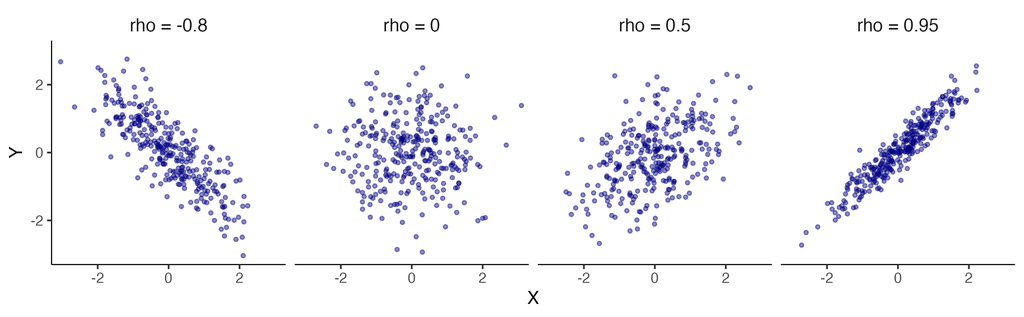

- Four clouds of 300 points, labeled with the $\rho$ that generated them.
- A correlation of $0.5$ is a real relationship and still a very wide cloud.

## Independent Implies Uncorrelated

Suppose $X$ and $Y$ are statistically independent. Then the covariance must equal 0:

$$\begin{align*}
\operatorname{Cov}(X, Y) &= E[XY] - E[X]\,E[Y] \\
&= E[X]\,E[Y] - E[X]\,E[Y] \\
&= 0
\end{align*}$$

Statistical independence implies linear independence (i.e. zero covariance; zero correlation).

But the converse is not true: zero covariance does not imply statistical independence.

## Uncorrelated Does Not Imply Independent

Let $X$ take the values $-1, 0, 1$ with probability $1/3$ each, and let $Y = X^2$. Then $Y$ is a *deterministic function* of $X$.

Compute the covariance:

$$E[X] = \tfrac{1}{3}(-1) + \tfrac{1}{3}(0) + \tfrac{1}{3}(1) = 0
\qquad
E[Y] = \tfrac{1}{3}(1) + \tfrac{1}{3}(0) + \tfrac{1}{3}(1) = \tfrac{2}{3}$$

Now the cross moment. Note $XY = X \cdot X^2 = X^3$:

$$E[XY] = E[X^3] = \tfrac{1}{3}(-1) + \tfrac{1}{3}(0) + \tfrac{1}{3}(1) = 0$$

$$\operatorname{Cov}(X, Y) = 0 - (0)\big(\tfrac{2}{3}\big) = 0$$

- Even though $X$ and $Y$ are perfectly dependent, they have zero covariance.
- The issue is that the dependence is non-linear, and covariance only measures linear dependence.

## Simple ideas about OLS regression

Suppose that $Y$ and $X$ are random variables and we want to fit a simple linear regression model that “explains” $Y$ using $X$.

$$Y = \alpha + \beta X + e$$

Where we choose the intercept ($\alpha$) and slop ($\beta$) so that the residual has mean zero and $Cov(e,X)=0$.

$$\begin{align}
Cov(Y, X) &= Cov(\alpha + \beta X + e, X) \\
Cov(Y, X &= Cov(\alpha, X) + \beta Cov(X, X) + Cov(e, X) \\
Cov(Y, X) &= 0 + \beta Var(X) + 0 \\
\frac{Cov(Y,X)}{Var(X)} &= \beta
\end{align}$$

## Covariance and Correlation in R

```r
pacman::p_load(data.table, fixest, wooldridge)
dt <- as.data.table(wage1)

# the two moments, then the correlation
dt[, cov(educ, lwage)]
dt[, cor(educ, lwage)]

# the slope formula, by hand
dt[, cov(educ, lwage) / var(educ)]

# the same number, from a regression
feols(lwage ~ educ, data = dt)
```

## Recap

- **Covariance** is $E[XY] - E[X]E[Y]$, and it measures linear co-movement in the units of $X$ times $Y$
- **Correlation** rescales it by the two standard deviations into $[-1, 1]$, bounded by Cauchy–Schwarz
- Covariance is **bilinear** (V4), and the variance of a sum carries a **cross term** (V5) unless the two are uncorrelated
- **Independent implies uncorrelated. Uncorrelated does not imply independent.**